# Nike Revenue Forecast

### Project details:

#### Domain: Retail

#### Project: Nike Revenue Forecast

#### Data: Nike_revenue.xlsx

#### Description

- Data has been collected quarterly on Nike’s revenue for the fiscal years 1999 through 2008; for instance, data for fiscal year 1999 refers to the time period from June 1, 1998 through May 31, 1999. For validation set, 2009 data has been provided.

#### Case questions

- Plot the data. Which time series components seem to be present in this series? Interpret the chart in practical terms.

#### Part I: Regression

- Build a regression candidate model(s) and use that model(s) to forecast Nike’s revenue for the validation set. Hint: residual diagnostics might be helpful in identifying potentially good candidate models
- Do the forecasts seem reasonable? Briefly discuss
- What is/are the value(s) of RMSE for the training set? What is/are the value(s) of RMSE for the validation set?

#### Part II: Smoothing methods

- Identify an appropriate smoothing model(s) you should use for Nike’s revenue forecasting and discuss why you selected this/these model(s).

#### Part III: Classical time series decomposition

- Perform time series decomposition on Nike sales revenue.

#### Part IV: ARIMA models

- Is the data stationary? How do you know? Is there a way to make non-stationary data stationary? How? Apply these ideas to Nike’s revenue data.

#### Final Objective

- Build forecasting models to forecast Nike’s revenue for 2010.
- Prepare a report to summarize your approach(es) and findings.
- You will need to convey statistical information in written form to those who may not know statistical terminology.
- Your report is needed as input for managerial decision making in sales, marketing, and company planning.

### Loading required packages

```r
library(forecast)
library(TTR)
library(Metrics)
library(tidyr)
library(dplyr)
```

### Revenues are provided for fiscal years 1999 to 2009. Here fiscal year means previous year June 1 to current year May 31

### Fiscal year 1999: June 1, 1998 to May 31,1999

```r
revenues <- read.csv('Nike_revenue.csv')
str(revenues)
```

```
## 'data.frame':    11 obs. of  5 variables:
##  $ X      : int  1999 2000 2001 2002 2003 2004 2005 2006 2007 2008 ...
##  $ X31.Aug: int  2505 2501 2637 2614 2796 3025 3562 3862 4194 4655 ...
##  $ X30.Nov: int  1913 2060 2199 2337 2515 2837 3148 3475 3822 4340 ...
##  $ X28.Feb: int  2177 2162 2170 2260 2401 2904 3308 3613 3927 4544 ...
##  $ X31.May: int  2182 2273 2483 2682 2985 3487 3721 4005 4383 5088 ...
```

### Formatting the data

```r
revenues_t <- as.data.frame(t(revenues[,2:5]))
revenues_t
```

```
##           V1   V2   V3   V4   V5   V6   V7   V8   V9  V10  V11
## X31.Aug 2505 2501 2637 2614 2796 3025 3562 3862 4194 4655 5432
## X30.Nov 1913 2060 2199 2337 2515 2837 3148 3475 3822 4340 4590
## X28.Feb 2177 2162 2170 2260 2401 2904 3308 3613 3927 4544 4440
## X31.May 2182 2273 2483 2682 2985 3487 3721 4005 4383 5088 4713
```

```r
revenues1 <- gather(revenues_t,"quarter","revenues",1:11)
revenues1 <- revenues1[,-1]
revenues1
```

```
##  [1] 2505 1913 2177 2182 2501 2060 2162 2273 2637 2199 2170 2483 2614 2337
## [15] 2260 2682 2796 2515 2401 2985 3025 2837 2904 3487 3562 3148 3308 3721
## [29] 3862 3475 3613 4005 4194 3822 3927 4383 4655 4340 4544 5088 5432 4590
## [43] 4440 4713
```

### Creating time series data

```r
revenuests <- ts(revenues1,start=c(1999,1),frequency = 4)
revenuests
```

```
##      Qtr1 Qtr2 Qtr3 Qtr4
## 1999 2505 1913 2177 2182
## 2000 2501 2060 2162 2273
## 2001 2637 2199 2170 2483
## 2002 2614 2337 2260 2682
## 2003 2796 2515 2401 2985
## 2004 3025 2837 2904 3487
## 2005 3562 3148 3308 3721
## 2006 3862 3475 3613 4005
## 2007 4194 3822 3927 4383
## 2008 4655 4340 4544 5088
## 2009 5432 4590 4440 4713
```

### Plotting the time series data

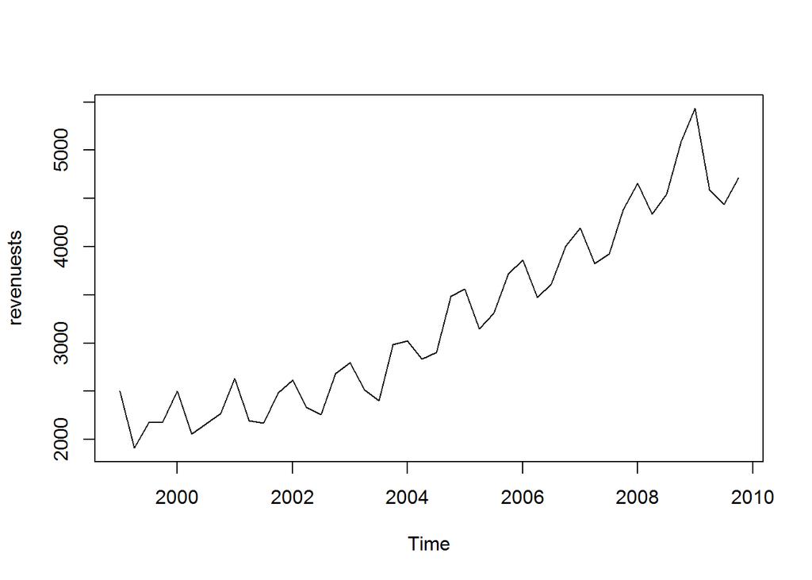

```r
plot(revenuests)
```

Can infer that:

- There is a upward rising trend
- The revenue is rising and falling at regular intervals of time. We can observe seasonal and cyclical patterns in the data.

### Seasonal trend decompostion

```r
seasonaldecom <- stl(revenuests,s.window = "periodic")
seasonaldecom
```

```
##  Call:
##  stl(x = revenuests, s.window = "periodic")
##
## Components
##          seasonal    trend   remainder
## 1999 Q1  257.1988 2221.927   25.874408
## 1999 Q2 -204.8485 2212.857  -95.008027
## 1999 Q3 -188.2011 2203.705  161.496414
## 1999 Q4  135.8508 2207.680 -161.531041
## 2000 Q1  257.1988 2221.315   22.486295
## 2000 Q2 -204.8485 2246.677   18.171718
## 2000 Q3 -188.2011 2266.010   84.190933
## 2000 Q4  135.8508 2293.446 -156.297109
## 2001 Q1  257.1988 2318.632   61.169598
## 2001 Q2 -204.8485 2353.622   50.226098
```

[output cut: 34 more lines]

Can infer that:

- Data is divided into seasonal, trend and remainder (unexplained) components
- Seasonal value is repeating itself every quarter (that is same value every Q1, same value every Q2/Q3/Q4)
- Trend is increasing mostly and decreasing in between but overall can find a rising trend from 2221 to 4565 millions (105% increase over a period of 10 years from 1999 to 2009)

### Plotting the Seasonal trend decompostion

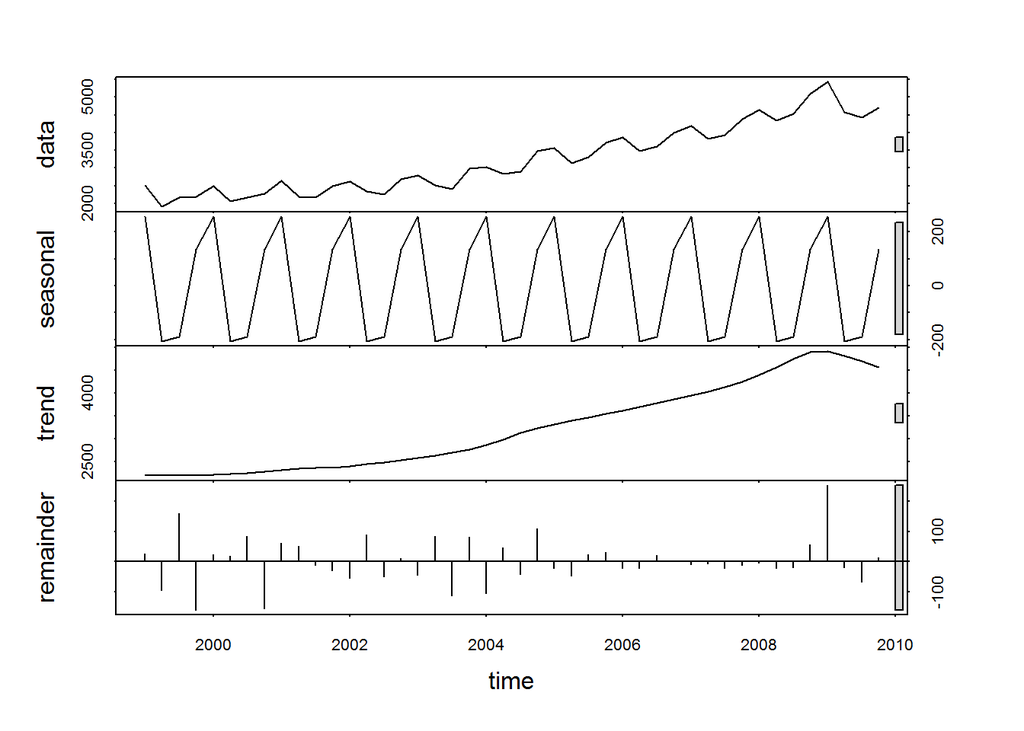

```r
plot(seasonaldecom)
```

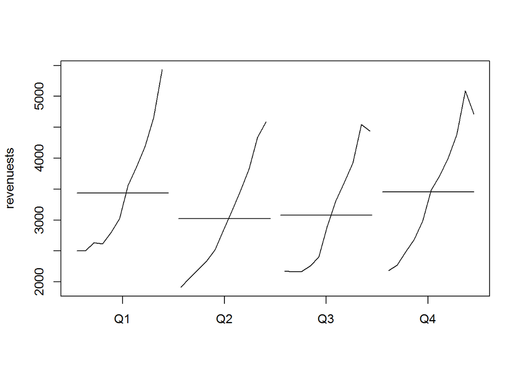

```r
monthplot(revenuests)
```

Can infer following from seasonal decomposition:

- Can find increase and decrease at regular intervals of time (from seasonal component)
- Can find steady increase in trend over the years. However from 2009 fiscal year Q2 (that is from Sep 2008) onwards the trend is falling
- There is some unexplainedn(remainder) portion too

Can infer following from overall quarterly plot (for all years put together):

- The revenues in all quarters have increased over the years
- The revenues in Q1 and Q4 are higher compared to the revenues in Q2 and Q3. Q2 got least revenues
- The revenues in Q3 and Q4 are decreasing off late (in 2009)

### Initialize the results table

```r
results <- NULL
results <- data.frame()
```

### Fit a Linear Model with Time Series componenets of Trend and Additive Seasonality

### Additive means data set has CONSTANT seasonality Variation

```r
# Additive
fitlmAdd <- tslm(revenuests ~ trend + season)
summary(fitlmAdd)
```

```
##
## Call:
## tslm(formula = revenuests ~ trend + season)
##
## Residuals:
##     Min      1Q  Median      3Q     Max
## -409.82 -155.23  -49.46  143.22  585.92
##
## Coefficients:
##             Estimate Std. Error t value Pr(>|t|)
## (Intercept) 1952.994     97.910  19.947  < 2e-16 ***
## trend         70.563      2.978  23.695  < 2e-16 ***
## season2     -483.927    106.583  -4.540 5.28e-05 ***
## season3     -493.581    106.708  -4.626 4.05e-05 ***
## season4     -191.780    106.915  -1.794   0.0806 .
## ---
## Signif. codes:  0 '***' 0.001 '**' 0.01 '*' 0.05 '.' 0.1 ' ' 1
##
## Residual standard error: 249.9 on 39 degrees of freedom
## Multiple R-squared:  0.9379, Adjusted R-squared:  0.9315
## F-statistic: 147.3 on 4 and 39 DF,  p-value: < 2.2e-16
```

```r
fort.fitlmAdd <- forecast(fitlmAdd, h=4)


# Accuracy

temp <- list(accuracy(fort.fitlmAdd)[,'RMSE'])
temp <- as.data.frame(temp,col.names = 'RMSE', row.names = 'lm_Add')


results <- rbind(results,temp)

results['lm_Add',]
```

```
## [1] 235.2373
```

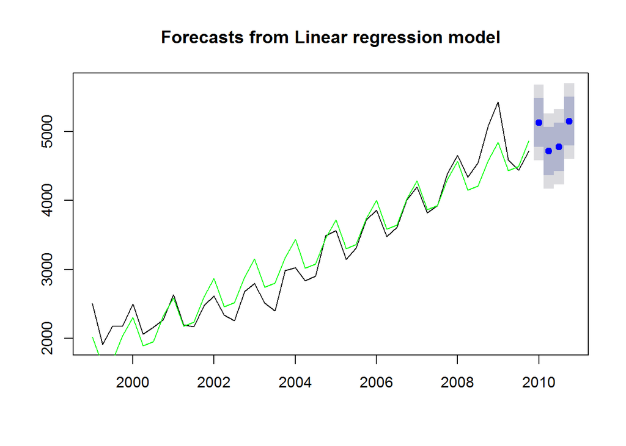

```r
# Plot the graph

p <- plot(fort.fitlmAdd)
lines(fort.fitlmAdd$fitted,col='green')
```

```r
print(p)
```

```
## $mean
##          Qtr1     Qtr2     Qtr3     Qtr4
## 2010 5128.332 4714.968 4775.877 5148.241
##
## $lower
##             [,1]     [,2]
## 2010 Q1 4775.591 4581.028
## 2010 Q2 4362.227 4167.665
## 2010 Q3 4423.136 4228.574
## 2010 Q4 4795.500 4600.937
##
## $upper
##             [,1]     [,2]
## 2010 Q1 5481.073 5675.635
## 2010 Q2 5067.709 5262.272
## 2010 Q3 5128.618 5323.181
## 2010 Q4 5500.982 5695.544
```

Can infer that:

- RMSE for the model is 235.2373

### Fit a Linear Model with Time Series componenets of Trend and Multiplicative Seasonality

### Multiplicative means data set has INCREASING or DECREASING Seasonality variation.

### Multiplicative will become additive if log of data is taken

```r
#Multiplicative
fitlmMul <- tslm(revenuests ~ trend * season)
summary(fitlmMul)
```

```
##
## Call:
## tslm(formula = revenuests ~ trend * season)
##
## Residuals:
##     Min      1Q  Median      3Q     Max
## -411.12 -159.67  -29.53  144.96  579.73
##
## Coefficients:
##               Estimate Std. Error t value Pr(>|t|)
## (Intercept)   1946.491    150.217  12.958 4.02e-15 ***
## trend           70.873      6.127  11.566 1.11e-13 ***
## season2       -439.186    216.206  -2.031   0.0497 *
## season3       -418.039    220.078  -1.899   0.0655 .
## season4       -291.600    224.052  -1.301   0.2014
## trend:season2   -2.048      8.666  -0.236   0.8145
## trend:season3   -3.311      8.666  -0.382   0.7046
## trend:season4    4.120      8.666   0.475   0.6373
## ---
## Signif. codes:  0 '***' 0.001 '**' 0.01 '*' 0.05 '.' 0.1 ' ' 1
##
## Residual standard error: 257.1 on 36 degrees of freedom
## Multiple R-squared:  0.9393, Adjusted R-squared:  0.9275
## F-statistic: 79.62 on 7 and 36 DF,  p-value: < 2.2e-16
```

```r
fort.fitlmMul <- forecast(fitlmMul, h=4)


# Accuracy

temp <- list(accuracy(fort.fitlmMul)[,'RMSE'])
temp <- as.data.frame(temp,col.names = 'RMSE', row.names = 'lm_Mul')


results <- rbind(results,temp)

results['lm_Mul',]
```

```
## [1] 232.5219
```

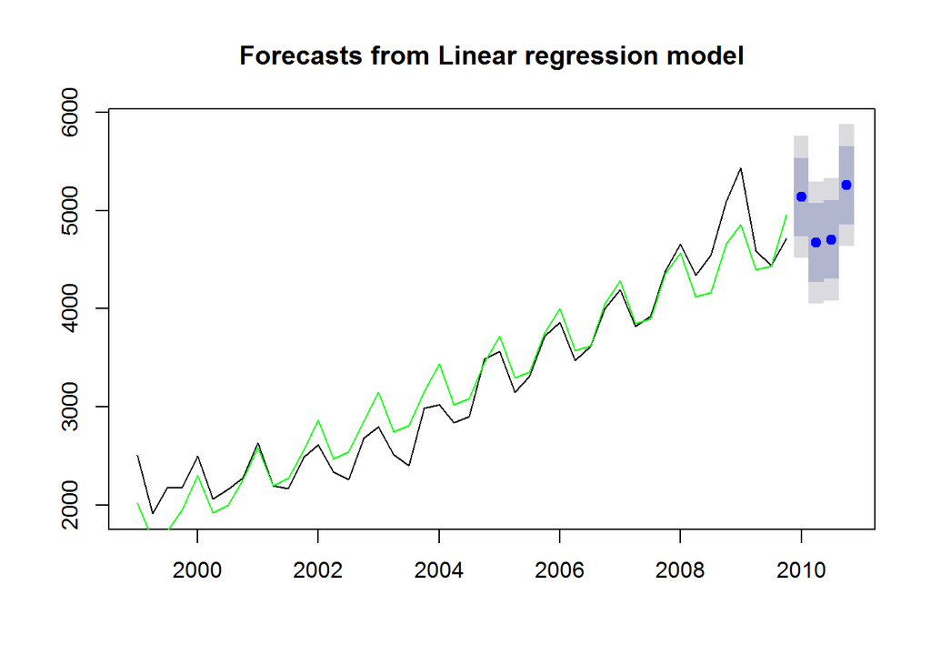

```r
# Plot the graph

p <- plot(fort.fitlmMul)
lines(fort.fitlmMul$fitted,col='green')
```

```r
print(p)
```

```
## $mean
##          Qtr1     Qtr2     Qtr3     Qtr4
## 2010 5135.764 4673.255 4703.836 5254.564
##
## $lower
##             [,1]     [,2]
## 2010 Q1 4736.108 4514.905
## 2010 Q2 4273.598 4052.395
## 2010 Q3 4304.180 4082.977
## 2010 Q4 4854.908 4633.705
##
## $upper
##             [,1]     [,2]
## 2010 Q1 5535.420 5756.623
## 2010 Q2 5072.911 5294.114
## 2010 Q3 5103.492 5324.695
## 2010 Q4 5654.220 5875.423
```

Can infer that:

- RMSE for the model is 232.5219

### Simple Moving Average

```r
#install.packages('smooth')
library(smooth)
```

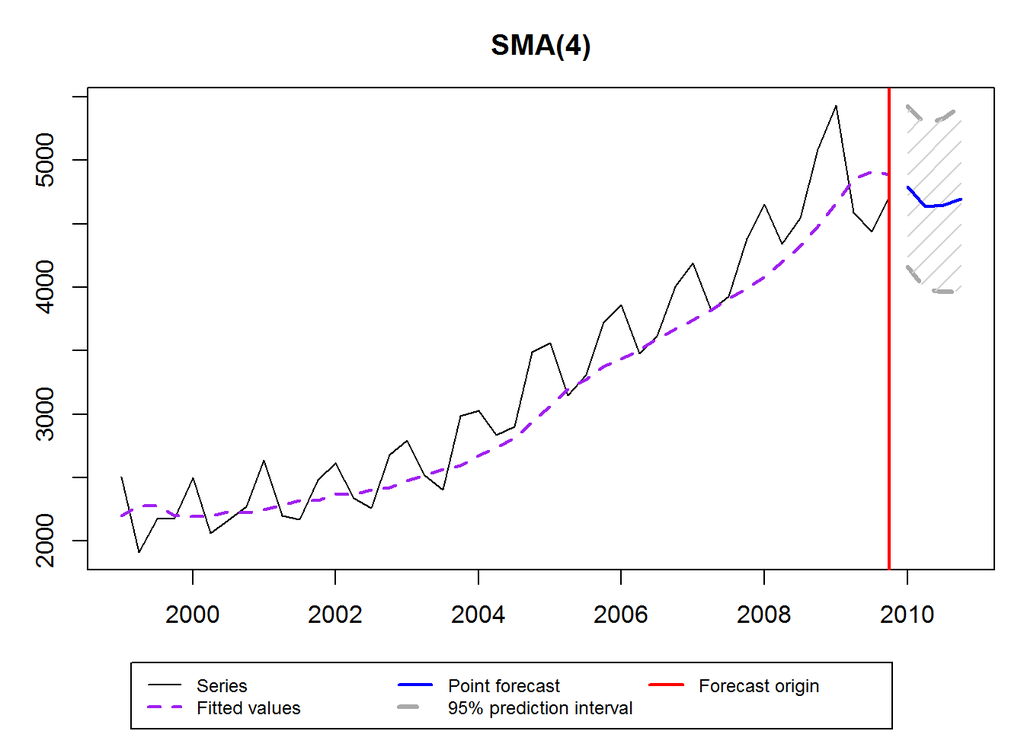

```r
SMAi <- sma(revenuests, h=4,silent="graph")

plot(forecast(SMAi,h=4))
```

```r
# Accuracy


temp <- list(sqrt(SMAi$cf))
temp <- as.data.frame(temp,col.names = 'RMSE', row.names = 'SMA')

results <- rbind(results,temp)

results['SMA',]
```

```
## [1] 307.3963
```

Can infer that:

- The best model is the one that took avearges over 4 quarters
- RMSE for the model is 307.3963

### Weighted moving average

```r
#weighted moving average model

WMAi <- WMA(revenuests, n = 4, w = c(0.49,0.01,0.01,0.49))
WMAi
```

```
##  [1]      NA      NA      NA 2337.53 2206.45 2122.96 2174.17 2381.48
##  [9] 2345.88 2185.99 2225.43 2552.49 2404.90 2259.40 2373.58 2641.01
## [17] 2564.59 2394.53 2543.78 2881.85 2768.46 2626.72 2944.23 3248.29
## [25] 3199.42 3035.97 3396.65 3633.23 3505.19 3399.50 3667.03 3925.71
## [33] 3833.99 3725.14 3966.84 4280.22 4236.83 4141.21 4464.18 4862.91
## [41] 4884.60 4580.86 4768.94 5061.35
```

```r
#Accuracy

temp <- list(rmse(revenues1[5:length(revenues1)],WMAi[4:(length(revenues1)-1)]))
temp <- as.data.frame(temp,col.names = 'RMSE', row.names = 'WMA')

results <- rbind(results,temp)

results['WMA',]
```

```
## [1] 266.9178
```

Can infer that:

- Given more weightage to 1st and 4th quarter are on high side and bit similar in nature
- RMSE for the model is 266.9178

### Single exponential smoothing

### Holt-Winters exponential smoothing without trend and without seasonal component.

```r
SES_Auto <- HoltWinters(revenuests,beta = FALSE,gamma=FALSE)
SES_Auto
```

```
## Holt-Winters exponential smoothing without trend and without seasonal component.
##
## Call:
## HoltWinters(x = revenuests, beta = FALSE, gamma = FALSE)
##
## Smoothing parameters:
##  alpha: 0.5891108
##  beta : FALSE
##  gamma: FALSE
##
## Coefficients:
##       [,1]
## a 4667.651
```

```r
SES_Auto_forcast <- forecast(SES_Auto,h=4)

# Accuracy

temp <- list(accuracy(SES_Auto_forcast)[,'RMSE'])
temp <- as.data.frame(temp,col.names = 'RMSE', row.names = 'SES')

results <- rbind(results,temp)

results['SES',]
```

```
## [1] 324.6692
```

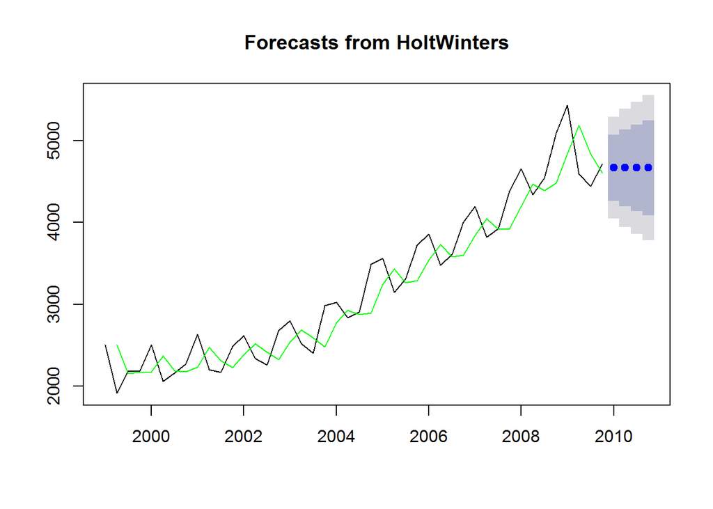

```r
# Plot the graph

p <- plot(SES_Auto_forcast)
lines(SES_Auto_forcast$fitted,col='green')
```

```r
print(p)
```

```
## $mean
##          Qtr1     Qtr2     Qtr3     Qtr4
## 2010 4667.651 4667.651 4667.651 4667.651
##
## $lower
##           80%      95%
## [1,] 4261.463 4046.439
## [2,] 4196.218 3946.657
## [3,] 4138.966 3859.096
## [4,] 4087.334 3780.132
##
## $upper
##           80%      95%
## [1,] 5073.840 5288.863
## [2,] 5139.084 5388.646
## [3,] 5196.337 5476.207
## [4,] 5247.969 5555.171
```

Can infer that:

- Data Smoothing parameter of 0.5891108 was choosen as best value
- RMSE for the model is 324.6692

### Double exponential smoothing

### Holt-Winters exponential smoothing with trend and without seasonal component.

```r
DES_Auto <- HoltWinters(revenuests,gamma=FALSE)
DES_Auto
```

```
## Holt-Winters exponential smoothing with trend and without seasonal component.
##
## Call:
## HoltWinters(x = revenuests, gamma = FALSE)
##
## Smoothing parameters:
##  alpha: 1
##  beta : 0.2001188
##  gamma: FALSE
##
## Coefficients:
##         [,1]
## a 4713.00000
## b   32.16753
```

```r
DES_Auto_forcast <- forecast(DES_Auto,h=4)

# Accuracy

temp <- list(accuracy(DES_Auto_forcast)[,'RMSE'])
temp <- as.data.frame(temp,col.names = 'RMSE', row.names = 'DES')

results <- rbind(results,temp)

results['DES',]
```

```
## [1] 390.5604
```

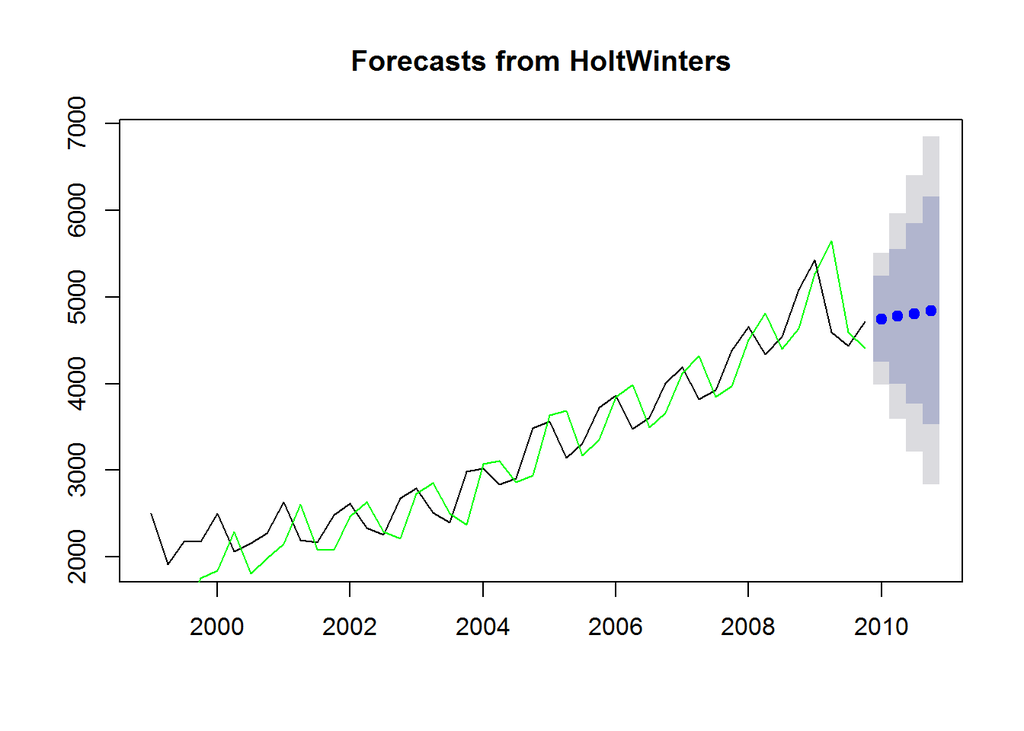

```r
# Plot the graph

p <- plot(DES_Auto_forcast)
lines(DES_Auto_forcast$fitted,col='green')
```

```r
print(p)
```

```
## $mean
##          Qtr1     Qtr2     Qtr3     Qtr4
## 2010 4745.168 4777.335 4809.503 4841.670
##
## $lower
##           80%      95%
## [1,] 4247.819 3984.539
## [2,] 4000.406 3589.125
## [3,] 3766.143 3213.821
## [4,] 3529.377 2834.692
##
## $upper
##           80%      95%
## [1,] 5242.516 5505.797
## [2,] 5554.264 5965.545
## [3,] 5852.862 6405.184
## [4,] 6153.963 6848.649
```

Can infer that:

- Data Smoothing parameter of 1 and Trend Smoothing parameter of 0.2001188 was choosen as best value
- RMSE for the model is 390.5604

### Triple exponential smoothing

### Holt-Winters exponential smoothing with trend and additive seasonal component.

```r
TES_Auto <- HoltWinters(revenuests)
TES_Auto
```

```
## Holt-Winters exponential smoothing with trend and additive seasonal component.
##
## Call:
## HoltWinters(x = revenuests)
##
## Smoothing parameters:
##  alpha: 0.5913811
##  beta : 0.9071079
##  gamma: 1
##
## Coefficients:
##         [,1]
## a  4525.4547
## b  -213.6998
## s1  329.8457
## s2 -394.2068
## s3 -297.2453
## s4  187.5453
```

```r
TES_Auto_forcast <- forecast(TES_Auto,h=4)

# Accuracy

temp <- list(accuracy(TES_Auto_forcast)[,'RMSE'])
temp <- as.data.frame(temp,col.names = 'RMSE', row.names = 'TES_Add')

results <- rbind(results,temp)

results['TES_Add',]
```

```
## [1] 142.0851
```

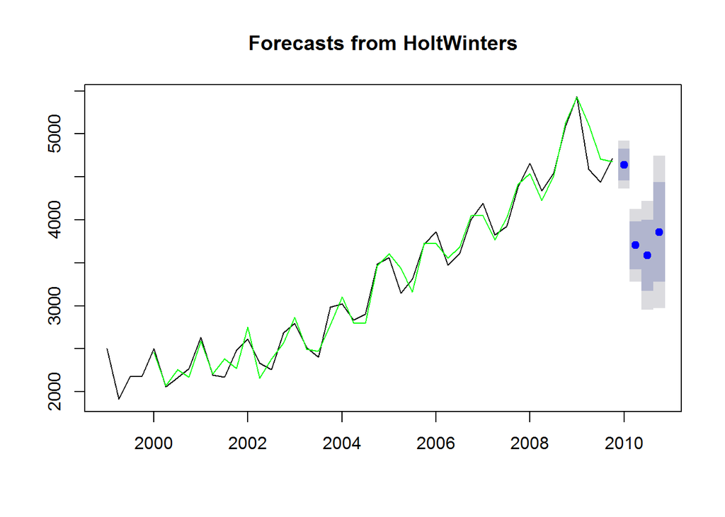

```r
# Plot the graph

p <- plot(TES_Auto_forcast)
lines(TES_Auto_forcast$fitted,col='green')
```

```r
print(p)
```

```
## $mean
##          Qtr1     Qtr2     Qtr3     Qtr4
## 2010 4641.601 3703.848 3587.110 3858.201
##
## $lower
##           80%      95%
## [1,] 4457.710 4360.365
## [2,] 3426.668 3279.937
## [3,] 3174.203 2955.623
## [4,] 3280.042 2973.984
##
## $upper
##           80%      95%
## [1,] 4825.491 4922.837
## [2,] 3981.029 4127.759
## [3,] 4000.017 4218.596
## [4,] 4436.359 4742.418
```

Can infer that:

- Data Smoothing parameter of 0.5913811, Trend Smoothing parameter of 0.9071079 and Seasonal Smoothing parameter of 1 was choosen as best value
- RMSE for the model is 142.0851

### Triple exponential smoothing

### Holt-Winters exponential smoothing with trend and multiplicative seasonal component.

```r
TES_Auto_M <- HoltWinters(revenuests,seasonal = c("multiplicative"))
TES_Auto_M
```

```
## Holt-Winters exponential smoothing with trend and multiplicative seasonal component.
##
## Call:
## HoltWinters(x = revenuests, seasonal = c("multiplicative"))
##
## Smoothing parameters:
##  alpha: 0.5816031
##  beta : 0.9082431
##  gamma: 1
##
## Coefficients:
##            [,1]
## a  4553.0756363
## b  -191.2979520
## s1    1.0724977
## s2    0.9255167
## s3    0.9360995
## s4    1.0351245
```

```r
TES_Auto_forcast_M <- forecast(TES_Auto_M,h=4)

# Accuracy

temp <- list(accuracy(TES_Auto_forcast_M)[,'RMSE'])
temp <- as.data.frame(temp,col.names = 'RMSE', row.names = 'TES_Mul')

results <- rbind(results,temp)

results['TES_Mul',]
```

```
## [1] 131.5695
```

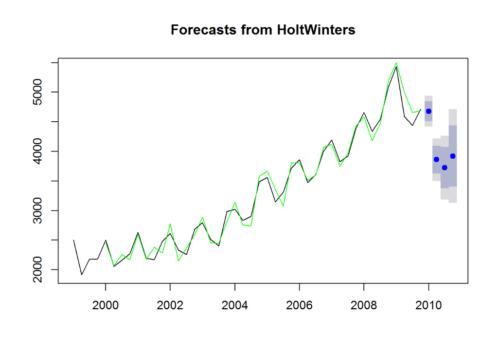

```r
# Plot the graph

p <- plot(TES_Auto_forcast_M)
lines(TES_Auto_forcast_M$fitted,col='green')
```

```r
print(p)
```

```
## $mean
##          Qtr1     Qtr2     Qtr3     Qtr4
## 2010 4677.997 3859.849 3724.910 3920.931
##
## $lower
##           80%      95%
## [1,] 4507.853 4417.784
## [2,] 3624.258 3499.544
## [3,] 3371.918 3185.055
## [4,] 3403.901 3130.202
##
## $upper
##           80%      95%
## [1,] 4848.140 4938.209
## [2,] 4095.439 4220.153
## [3,] 4077.903 4264.766
## [4,] 4437.961 4711.661
```

Can infer that:

- Data Smoothing parameter of 0.5816031, Trend Smoothing parameter of 0.9082431 and Seasonal Smoothing parameter of 1 was choosen as best value
- RMSE for the model is 131.5695

### ARIMA (Auto regressive Integrated Moving Average)

```r
ARIMA_model <- auto.arima(revenuests)
summary(ARIMA_model)
```

```
## Series: revenuests
## ARIMA(0,1,0)(0,1,0)[4]
##
## sigma^2 estimated as 23139:  log likelihood=-251.3
## AIC=504.6   AICc=504.71   BIC=506.26
##
## Training set error measures:
##                     ME     RMSE      MAE         MPE     MAPE     MASE
## Training set -8.506348 143.2124 97.68729 -0.06673682 3.046453 0.341564
##                   ACF1
## Training set 0.0504961
```

```r
ARIMA_model_forcast <- forecast(ARIMA_model,h=4)

# Accuracy

temp <- list(accuracy(ARIMA_model_forcast)[,'RMSE'])
temp <- as.data.frame(temp,col.names = 'RMSE', row.names = 'ARIMA')

results <- rbind(results,temp)

results['ARIMA',]
```

```
## [1] 143.2124
```

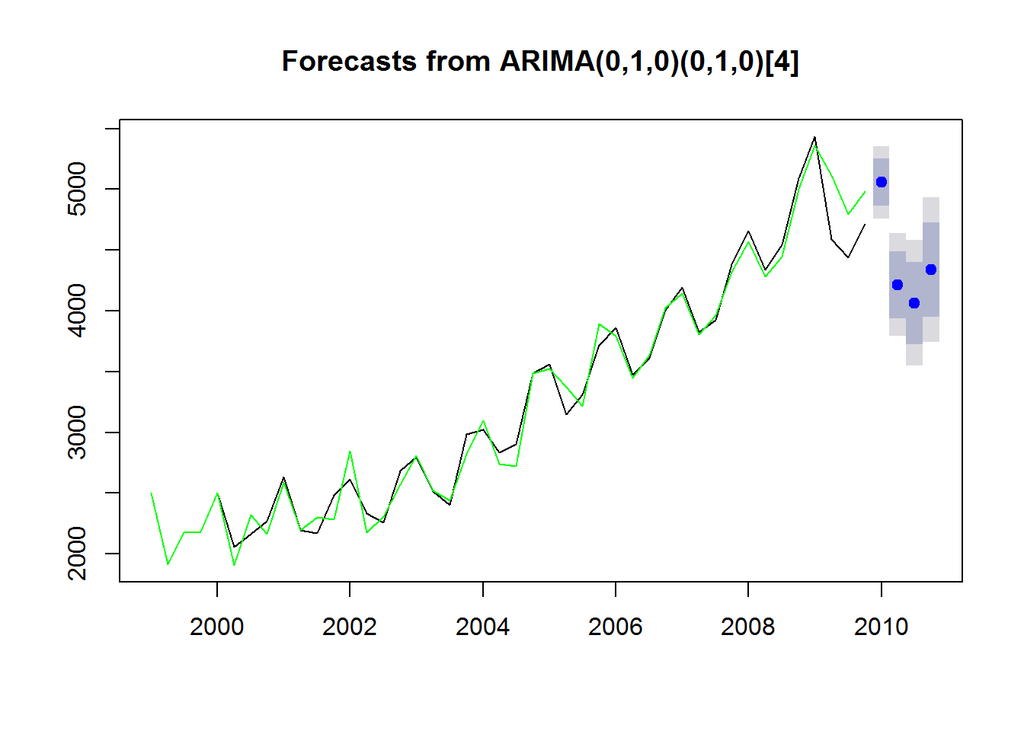

```r
# Plot the graph

p <- plot(ARIMA_model_forcast)
lines(ARIMA_model_forcast$fitted,col='green')
```

```r
print(p)
```

```
## $mean
##      Qtr1 Qtr2 Qtr3 Qtr4
## 2010 5057 4215 4065 4338
##
## $lower
##              80%      95%
## 2010 Q1 4862.056 4758.858
## 2010 Q2 3939.307 3793.364
## 2010 Q3 3727.346 3548.603
## 2010 Q4 3948.111 3741.716
##
## $upper
##              80%      95%
## 2010 Q1 5251.944 5355.142
## 2010 Q2 4490.693 4636.636
## 2010 Q3 4402.654 4581.397
## 2010 Q4 4727.889 4934.284
```

Can infer that:

- Seasonal ARIMA model is used : ARIMA(0,1,0)(0,1,0)[4]
- The model includes a non-seasonal differencing I(1) term, a seasonal differencing I(1) term, no AR, no MA terms and the seasonal period is S = 4.
- RMSE for the model is 143.2124

### Comparing the various time series models

```r
results
```

```
##             RMSE
## lm_Add  235.2373
## lm_Mul  232.5219
## SMA     307.3963
## WMA     266.9178
## SES     324.6692
## DES     390.5604
## TES_Add 142.0851
## TES_Mul 131.5695
## ARIMA   143.2124
```

```r
idx <- which(results==min(results))
cat('The model selected as the best one is:',row.names(results)[idx],'\nThe RMSE for the model is:',min(results))
```

```
## The model selected as the best one is: TES_Mul
## The RMSE for the model is: 131.5695
```

### Create file with final prediction values(for fiscal year 2010) from the best model

```r
write.csv(TES_Auto_forcast_M$mean,"Nike_revenue_forecast_2010.csv")
TES_Auto_forcast_M$mean
```

```
##          Qtr1     Qtr2     Qtr3     Qtr4
## 2010 4677.997 3859.849 3724.910 3920.931
```

### Conclusion:

- It is predicted that revenues are going to decrease largely
- It is recommended that marketing team plan certain promotional offers during 2010 Q1 so that estimated dip in sales can be taken care of and revenues be improved from 2010 Q2 onwards.